# Chapter 3: The Beta-Binomial Bayesian Model

Simplified by Dr. Rajitha M. Silva

## Section 3.1: The Beta Prior Model

In Bayesian analysis, we begin with a prior belief about the parameter we want to estimate. In this case, we are interested in:

$$\pi = \text{Proportion of Minnesotans who currently support Michelle for
president}$$

Instead of treating $\pi$ as a single fixed value, we treat it as a **random variable** that reflects our uncertainty. Since $\pi$ must be between 0 and 1, a suitable distribution is the **Beta distribution**.

### 3.1.1 Understanding the Beta Distribution

The Beta distribution is defined by two positive shape parameters, $\alpha$ and $\beta$, and is written as:

$$\pi \sim \text{Beta}(\alpha, \beta)$$

Its probability density function is:

$$f(\pi) = \frac{\Gamma(\alpha + \beta)}{\Gamma(\alpha)\Gamma(\beta)}
\cdot \pi^{\alpha - 1}(1 - \pi)^{\beta - 1}$$

where $\Gamma(\cdot)$ is the Gamma function (a generalization of the factorial).

The Beta distribution is very flexible. It can take many shapes depending on $\alpha$ and $\beta$.

#### Visualizing Beta Distributions

Let us plot several Beta distributions with different values of $\alpha$ and $\beta$.

##### R Code

```r
library(bayesrules)
library(tidyverse)
```

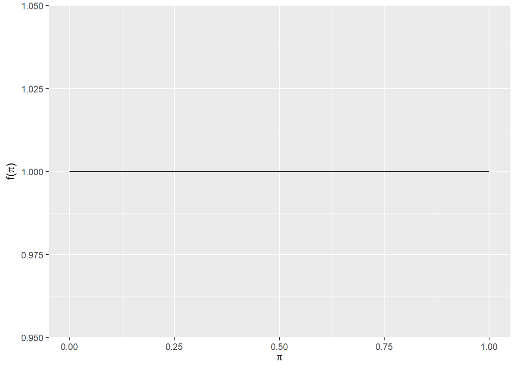

```r
# Examples of different Beta distributions
plot_beta(1, 1)     # Uniform distribution
```

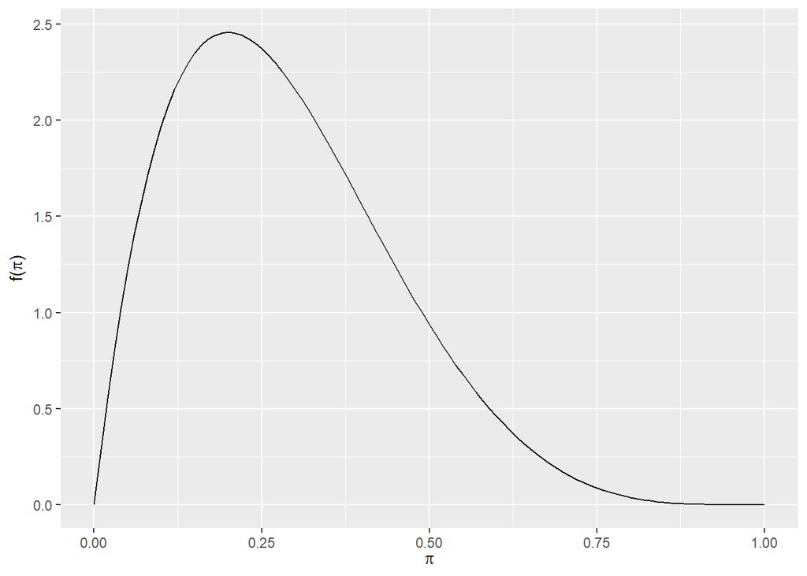

```r
plot_beta(2, 5)     # Skewed right
```

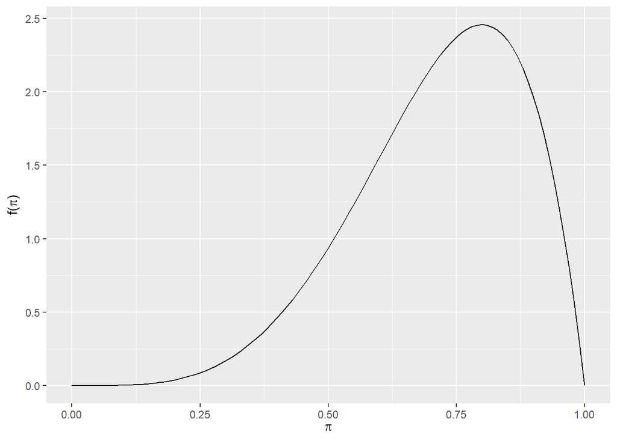

```r
plot_beta(5, 2)     # Skewed left
```

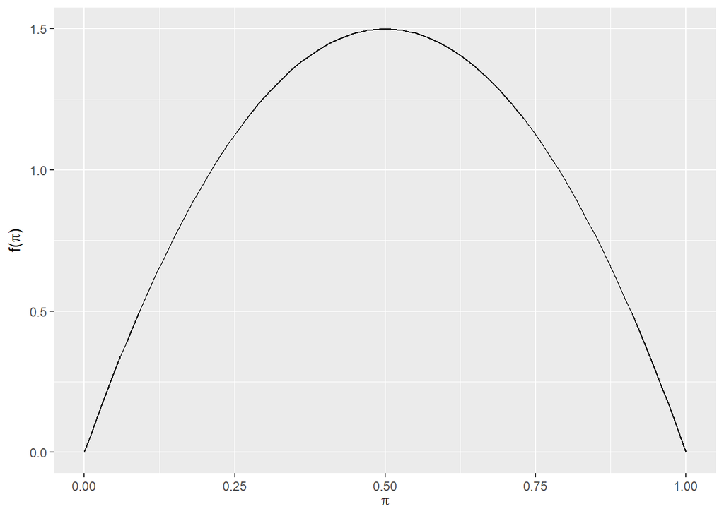

```r
plot_beta(2, 2)     # Symmetric with wide spread
```

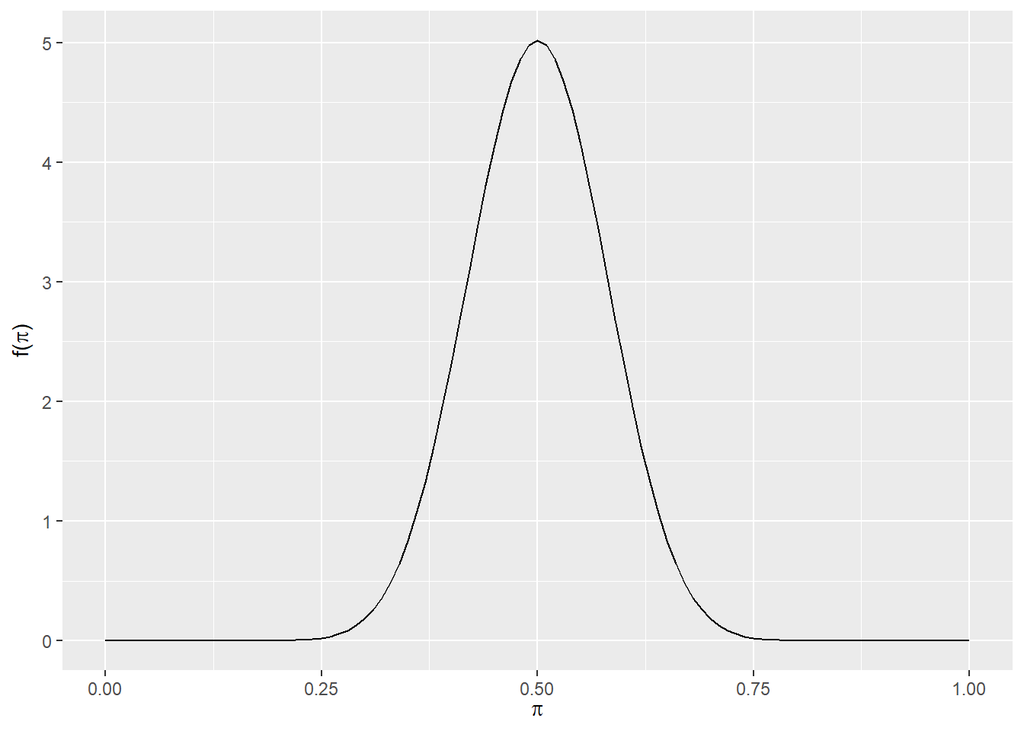

```r
plot_beta(20, 20)   # Symmetric with narrow spread
```

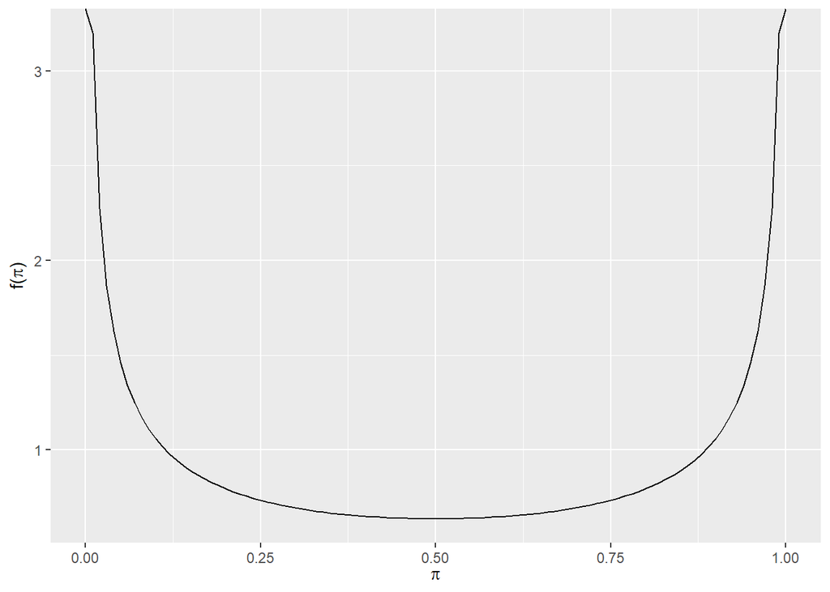

```r
plot_beta(0.5, 0.5) # U-shaped
```

##### Python Code

```python
import numpy as np
import matplotlib.pyplot as plt
import scipy.stats as stats

# Create a grid of ?? values
pi_vals = np.linspace(0.01, 0.99, 500)

# List of (alpha, beta) values
params = [(1,1), (2,5), (5,2), (2,2), (20,20), (0.5,0.5)]

plt.figure(figsize=(10, 6))
for a, b in params:
    pdf_vals = stats.beta.pdf(pi_vals, a, b)
    plt.plot(pi_vals, pdf_vals, label=f'Beta({a},{b})')

plt.title("Various Shapes of the Beta Distribution")
plt.xlabel("??")
plt.ylabel("Density")
plt.legend()
plt.grid(True)
plt.show()
```

### 3.1.2 Summary Measures of the Beta Distribution

To interpret a Beta distribution, we examine its **mean**, **mode**, and **variance**.

Formulas:

- Mean: $\mu = \frac{\alpha}{\alpha + \beta}$
- Mode: $\text{mode} = \frac{\alpha - 1}{\alpha + \beta - 2}$ (valid for $\alpha, \beta > 1$)
- Variance: $\frac{\alpha \beta}{(\alpha + \beta)^2 (\alpha + \beta + 1)}$
- Standard deviation: square root of the variance

#### R Code

```r
alpha <- 5
beta <- 2

mean_beta <- alpha / (alpha + beta)
mode_beta <- (alpha - 1) / (alpha + beta - 2)
var_beta <- (alpha * beta) / (((alpha + beta)^2) * (alpha + beta + 1))
sd_beta <- sqrt(var_beta)

c(mean = mean_beta, mode = mode_beta, sd = sd_beta)
```

```
##      mean      mode        sd
## 0.7142857 0.8000000 0.1597191
```

#### Python Code

```python
a, b = 5, 2

mean = a / (a + b)
mode = (a - 1) / (a + b - 2) if a > 1 and b > 1 else None
variance = (a * b) / ((a + b)**2 * (a + b + 1))
sd = np.sqrt(variance)

mean, mode, sd
```

### 3.1.3 Special Case: Uniform Distribution

If we have no prior preference for any value of $\pi$ between 0 and 1, we use a **uniform prior**:

$$\pi \sim \text{Beta}(1, 1)$$

This reflects complete uncertainty.

#### R Code

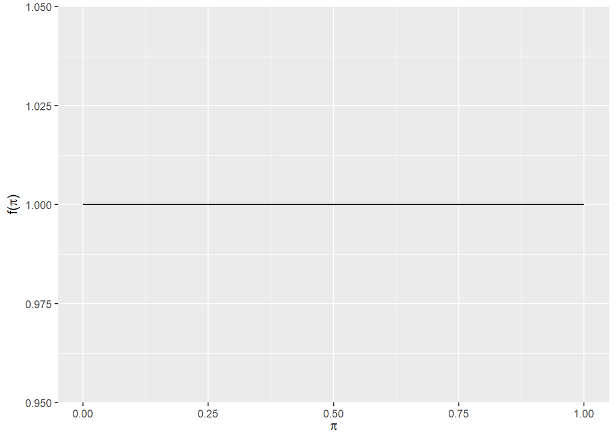

```r
plot_beta(1, 1)
```

#### Python Code

```python
a, b = 1, 1
pdf_uniform = stats.beta.pdf(pi_vals, a, b)

plt.figure(figsize=(8, 4))
plt.plot(pi_vals, pdf_uniform, label="Beta(1,1) = Uniform(0,1)")
plt.title("Uniform Prior Distribution (Beta(1,1))")
plt.xlabel("??")
plt.ylabel("Density")
plt.grid(True)
plt.legend()
plt.show()
```

## Section 3.1.2: Tuning the Beta Prior

In real-world Bayesian analysis, we do not pick Beta prior parameters ($\alpha, \beta$) randomly. We choose them to reflect **prior information** or beliefs. These parameters affect both the **center** and the **spread** of the distribution.

### Example: Michelle’s Polling Support

Michelle is running for president, and you are her campaign manager. Over 30 past polls, her support ranged from **25% to 65%**, with an average near **45%**.

We want a prior centered around 0.45, with enough weight to reflect the historical range.

### Step 1: Use the Mean Formula

The Beta distribution has mean:

$$\text{E}(\pi) = \frac{\alpha}{\alpha + \beta}$$

To reflect the average 45% support:

$$\frac{\alpha}{\alpha + \beta} = 0.45 \Rightarrow \alpha = \frac{9}{11}
\beta$$

We try integer multiples of (9,11) to get different strengths of prior belief.

### Try Beta(9,11), Beta(27,33), and Beta(45,55)

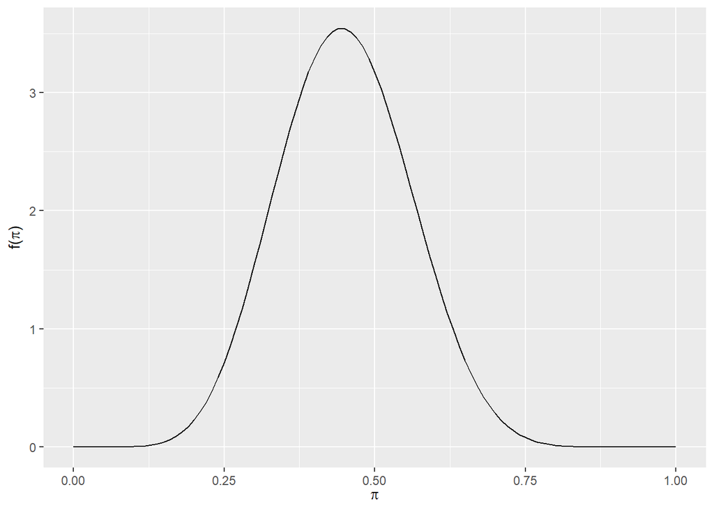

```r
library(bayesrules)
library(tidyverse)

# Visual comparison of different scales of the 9:11 ratio
plot_beta(9, 11)
```

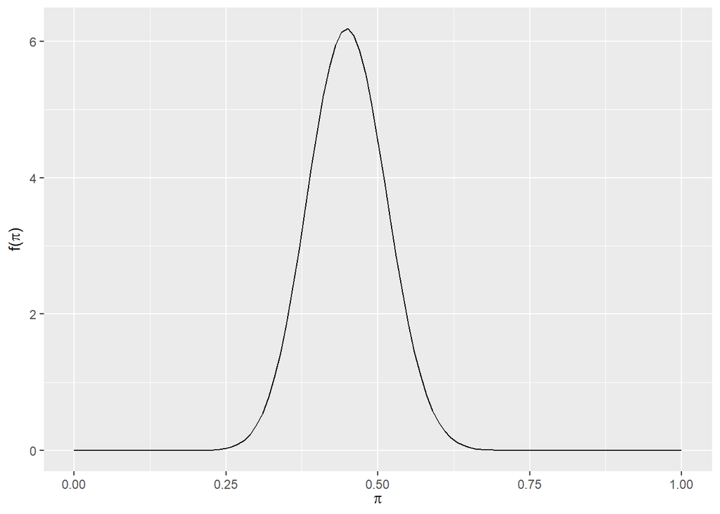

```r
plot_beta(27, 33)
```

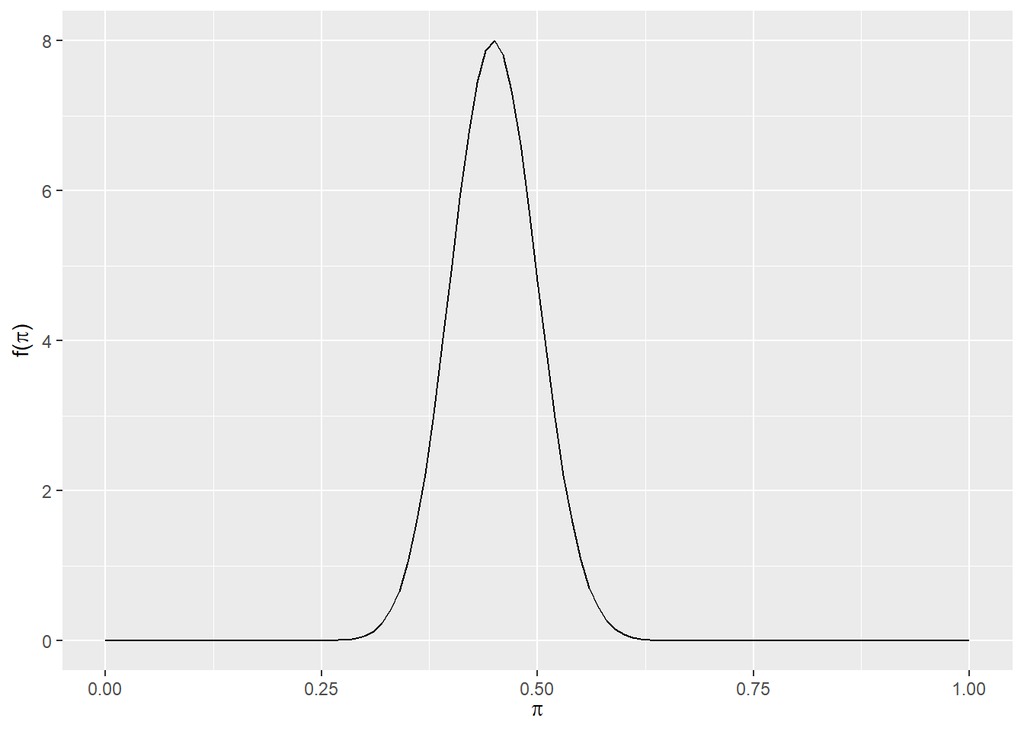

```r
plot_beta(45, 55)
```

The Beta(45,55) gives a prior centered at 0.45 with relatively low variability - a good match for Michelle’s prior support from 30 polls.

### Step 2: Confirm Mean, Mode, and Standard Deviation

```r
alpha <- 45
beta <- 55

mean <- alpha / (alpha + beta)
mode <- (alpha - 1) / (alpha + beta - 2)
var <- (alpha * beta) / ((alpha + beta)^2 * (alpha + beta + 1))
sd <- sqrt(var)

tibble(mean, mode, sd)
```

```
## # A tibble: 1 x 3
##    mean  mode     sd
##   <dbl> <dbl>  <dbl>
## 1  0.45 0.449 0.0495
```

### Interpretation

This prior suggests:

- Michelle’s expected support is **45%**
- The most likely value (mode) is **around 0.449**
- The standard deviation is about **0.05**, indicating moderate uncertainty

So, this Beta(45,55) prior will be used in the next section as a formal summary of prior beliefs before seeing the new polling data.

## Section 3.2: The Binomial Data Model and Likelihood Function

In the Bayesian framework, we combine prior beliefs with observed data through a model. After specifying the **prior**, the next step is to specify the **data model**, which describes how the data relate to the parameter of interest.

### Modeling New Poll Data

Suppose you now conduct a new poll of 50 Minnesotans and observe that **30** of them support Michelle.

We model this situation using the **Binomial distribution**, which is suitable for counting the number of successes (supporters) in a fixed number of independent trials (poll respondents).

### The Binomial Model

If $\pi$ is the probability of success, then the number of successes $Y$ in $n$ trials is:

$$Y \mid \pi \sim \text{Binomial}(n = 50, \pi)$$

In our case:

- $Y = 30$ people supported Michelle
- $n = 50$ total people were polled

The **likelihood function** describes how likely we are to observe $Y = 30$ given various values of $\pi$.

### Likelihood Function Definition

$$L(\pi \mid Y = 30) = \binom{50}{30} \pi^{30} (1 - \pi)^{20}$$

This function tells us: *If Michelle’s true support was $\pi$, how likely would we be to observe exactly 30 supporters out of 50?*

### R Code: Plotting the Likelihood Function

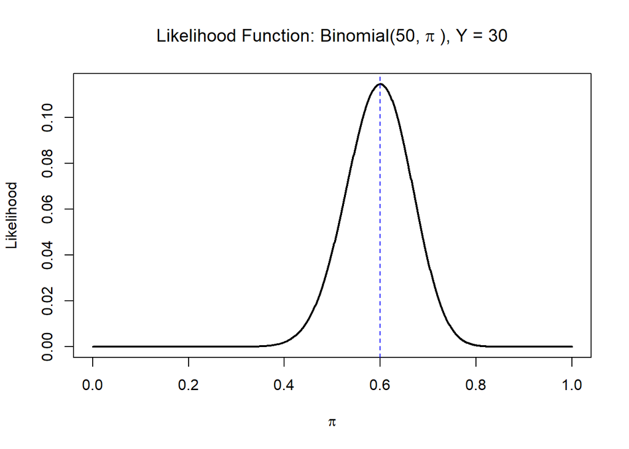

```r
# Define the likelihood function
likelihood <- function(pi) {
  dbinom(30, size = 50, prob = pi)
}

# Evaluate likelihood across a grid of ?? values
pi_vals <- seq(0, 1, length.out = 1000)
lik_vals <- likelihood(pi_vals)

# Plot the likelihood function
plot(pi_vals, lik_vals, type = "l", lwd = 2,
     xlab = expression(pi),
     ylab = "Likelihood",
     main = expression("Likelihood Function: Binomial(50," ~ pi ~ "), Y = 30"))
abline(v = 0.6, col = "blue", lty = 2)  # mode at ?? = 0.6
```

This shows that the **most likely** value of $\pi$ given the data is 0.6. That is, if Michelle’s true support were 60%, we’d most likely observe 30 out of 50 supporters.

### Key Insight

- The likelihood is **not a probability distribution** - it does not integrate to 1.
- It helps compare how compatible different values of $\pi$ are with the observed data.
- The **peak** of the likelihood occurs at $\pi = \frac{30}{50} = 0.6$, which is the **maximum likelihood estimate (MLE)**.

We will now combine this likelihood with our prior (Beta(45,55)) in the next section to form the **posterior distribution**.

## Section 3.3: The Beta Posterior Model

We now combine our prior knowledge about Michelle’s support (prior) with the new polling data (likelihood) to form an updated belief - the **posterior distribution**.

This is the central idea in Bayesian analysis.

### Bayes’ Rule (for continuous distributions)

$$f(\pi \mid Y = 30) = \frac{f(\pi) \cdot L(\pi \mid Y = 30)}{\int_0^1
f(\pi) \cdot L(\pi \mid Y = 30) \, d\pi}$$

In words:  
**Posterior** = **(Prior × Likelihood) / Constant**

### Prior and Likelihood for Michelle

- Prior: $\pi \sim \text{Beta}(45, 55)$
- Likelihood: $Y \mid \pi \sim \text{Binomial}(50, \pi)$, with $Y = 30$

### Conjugate Prior

A **conjugate prior** is a prior distribution that, when combined with a likelihood from a particular model family, results in a **posterior distribution from the same family**.

In this case:

- The **Beta distribution** is a **conjugate prior** for the **Binomial likelihood**.
- This means if we use a Beta prior with a Binomial data model, the resulting posterior will also be a Beta distribution.

Formally:

> We say that $f(\pi)$ is a **conjugate prior** for $L(\pi \mid y)$ if the posterior  
> $f(\pi \mid y) \propto f(\pi) \cdot L(\pi \mid y)$  
> is from the **same model family** as the prior.

Because the **Beta** prior is conjugate to the **Binomial** likelihood, the posterior is also Beta-distributed:

$$\pi \mid Y = 30 \sim \text{Beta}(45 + 30, 55 + 20) = \text{Beta}(75, 75)$$

### R Code: Plotting the Posterior

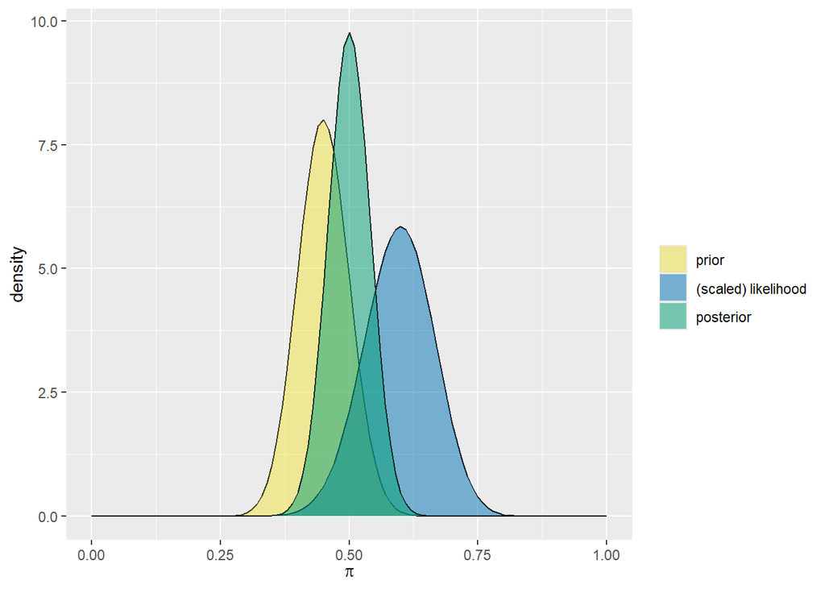

```r
# Visualize prior, likelihood (scaled), and posterior
plot_beta_binomial(alpha = 45, beta = 55, y = 30, n = 50)
```

This plot shows: - The **prior** (yellow) - The **likelihood**, scaled to have area 1 (blue) - The **posterior** (green), a compromise between prior and likelihood

### Summary of Posterior Characteristics

We use `summarize_beta_binomial()` to extract key quantities like mean, mode, variance, and standard deviation.

```r
# Summarize prior and posterior
summarize_beta_binomial(alpha = 45, beta = 55, y = 30, n = 50)
```

```
##       model alpha beta mean      mode         var         sd
## 1     prior    45   55 0.45 0.4489796 0.002450495 0.04950248
## 2 posterior    75   75 0.50 0.5000000 0.001655629 0.04068942
```

### Interpretation

- The new data nudges the mean support up from **45%** to **50%**
- The posterior is **more concentrated** (smaller standard deviation) than the prior
- We now have stronger belief that Michelle’s support is near 50%

This reflects a Bayesian learning process: we updated prior beliefs with new evidence.

In the next section, we will generalize this to a full **Beta-Binomial model** applicable to any number of trials and any prior.

## Section 3.4: The General Beta-Binomial Model

In the previous section, we applied Bayesian updating to Michelle’s support using:

- A **Beta(45, 55)** prior
- A **Binomial(50, $\pi$)** likelihood
- Observed data $Y = 30$

The result was a posterior:
$$\pi \mid Y = 30 \sim \text{Beta}(75, 75)$$

### Generalizing: The Beta-Binomial Model

This approach generalizes to many settings where we estimate a proportion $\pi \in [0, 1]$, and we observe:

- $Y$: number of successes (e.g., voters, defective items)
- $n$: total number of trials
- $\pi$: unknown proportion (e.g., support rate, failure rate)

We assume:

$$Y \mid \pi \sim \text{Binomial}(n, \pi)
\quad \text{and} \quad
\pi \sim \text{Beta}(\alpha, \beta)$$

Then the posterior is also a Beta distribution:
$$\pi \mid Y = y \sim \text{Beta}(\alpha + y, \beta + n - y)$$

### Posterior Summaries

The key formulas for the **posterior** $\text{Beta}(\alpha + y, \beta + n - y)$ are:

- **Mean**:
  $$\mathbb{E}(\pi \mid Y = y) = \frac{\alpha + y}{\alpha + \beta + n}$$
- **Mode** (when $\alpha + y > 1$ and $\beta + n - y > 1$):
  $$\text{Mode}(\pi \mid Y = y) = \frac{\alpha + y - 1}{\alpha + \beta + n -
  2}$$
- **Variance**:
  $$\text{Var}(\pi \mid Y = y) = \frac{(\alpha + y)(\beta + n - y)}{(\alpha
  + \beta + n)^2(\alpha + \beta + n + 1)}$$

### R Code: A General Example

Suppose we start with a prior $\pi \sim \text{Beta}(3, 3)$ and observe $Y = 12$ out of $n = 20$ trials.

```r
# Use summarize_beta_binomial() to compute updated values
summarize_beta_binomial(alpha = 3, beta = 3, y = 12, n = 20)
```

```
##       model alpha beta      mean      mode         var         sd
## 1     prior     3    3 0.5000000 0.5000000 0.035714286 0.18898224
## 2 posterior    15   11 0.5769231 0.5833333 0.009040105 0.09507947
```

### R Code: Plot Prior, Likelihood, and Posterior

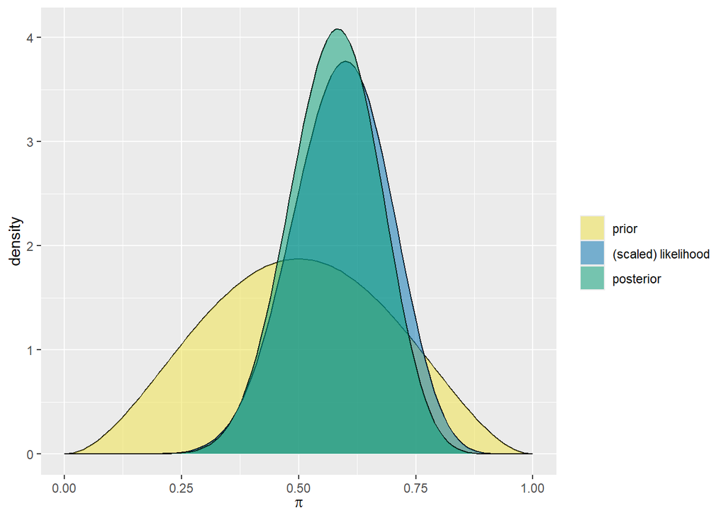

```r
# Visualize prior, scaled likelihood, and posterior
plot_beta_binomial(alpha = 3, beta = 3, y = 12, n = 20)
```

The **Beta-Binomial model** is a powerful and flexible Bayesian tool for:

- Proportions
- Probabilities
- Rates in [0,1]

It has wide applications, including:

- Medical test sensitivity/specificity
- Political polling
- Manufacturing quality rates

In the next section, we will simulate this model using random sampling to better understand its behavior.

## Section 3.5: Simulating the Beta-Binomial

Bayesian inference often involves computing the **posterior distribution** of an unknown parameter - like a proportion $\pi$. When conjugate priors are used (e.g., Beta prior with Binomial data), we get a closed-form posterior. But even then, simulation helps us:

- Visualize the relationship between parameter values and outcomes
- Approximate the posterior distribution (when closed form isn’t feasible)
- Estimate summaries (mean, SD, quantiles) empirically
- Understand the process of Bayesian updating more intuitively

### Scenario: Revisiting Michelle’s Support

Recall:

- Prior: $\pi \sim \text{Beta}(45, 55)$
- Poll: $n = 50$ people, with $Y = 30$ supporting Michelle
- Likelihood: $Y \mid \pi \sim \text{Binomial}(50, \pi)$

We will now simulate the prior and poll outcomes, and use these simulations to approximate the posterior distribution.

### Step 1: Simulate Prior $\pi$ Values

We draw 10,000 values from the prior $\text{Beta}(45, 55)$. Each value represents a possible “true” support rate for Michelle, according to our prior belief.

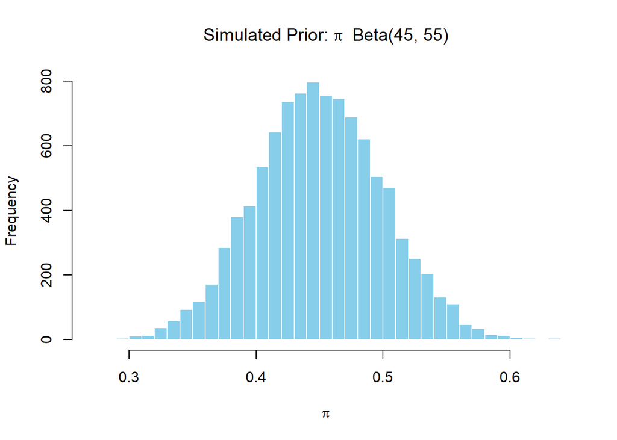

```r
set.seed(84735)

# Simulate 10,000 ?? values from the prior
pi_sim <- rbeta(10000, shape1 = 45, shape2 = 55)

# View a histogram of simulated ?? values
hist(pi_sim, breaks = 50, main = expression("Simulated Prior:" ~ pi ~ " Beta(45, 55)"),
     xlab = expression(pi), col = "skyblue", border = "white")
```

### Step 2: Simulate Data for Each Prior $\pi$

For each simulated $\pi$, simulate a poll result: how many people out of 50 would support Michelle?

```r
# Simulate polling outcomes Y for each pi
y_sim <- rbinom(10000, size = 50, prob = pi_sim)

# Combine into a data frame
michelle_sim <- data.frame(pi = pi_sim, y = y_sim)
```

This simulates what could happen **if** Michelle’s support was drawn from the prior - some scenarios give high support, some low, most around 45%.

### Step 3: Filter to Simulations Matching the Observed Data

We now filter the 10,000 simulations to only those where the poll result was **exactly 30 out of 50** (i.e., $Y = 30$). These represent prior values of $\pi$ that are **consistent with the observed data**.

```r
# Keep only simulated pi values where Y = 30
michelle_posterior <- michelle_sim %>% filter(y == 30)
```

### Step 4: Visualize the Simulated Posterior

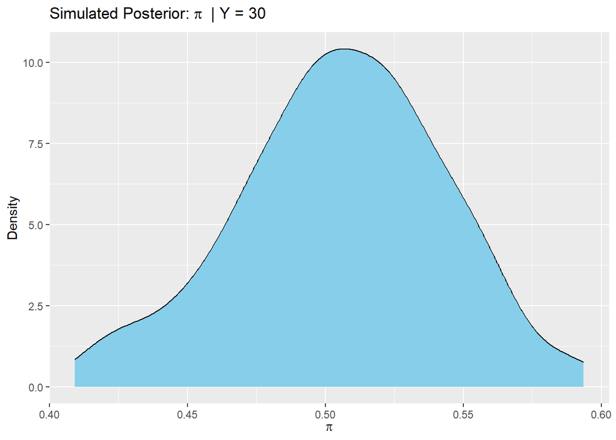

```r
# Plot the density of posterior pi values
ggplot(michelle_posterior, aes(x = pi)) +
  geom_density(fill = "skyblue") +
  labs(title = expression("Simulated Posterior:" ~ pi ~ " | Y = 30"),
       x = expression(pi), y = "Density")
```

This approximates the **posterior distribution** of $\pi$, given the data $Y = 30$. We expect the shape to resemble the analytical posterior $\text{Beta}(75, 75)$.

### Step 5: Summarize the Simulated Posterior

```r
# Mean and SD of the simulated posterior
michelle_posterior %>%
  summarize(mean_pi = mean(pi), sd_pi = sd(pi))
```

```
##     mean_pi      sd_pi
## 1 0.5054909 0.03732097
```

Compare this with theoretical values from $\text{Beta}(75, 75)$: - Mean = 0.50 - SD $\approx$ 0.0407

So our simulation provides a **very good approximation** of the posterior.

### Why Simulation is Important

Even though we had a closed-form posterior in this case, simulation is important for several reasons:

1. **Visualization**: Simulated distributions help us understand Bayesian updating intuitively.
2. **Approximation**: Many real-world models (non-conjugate, hierarchical) don’t yield closed-form posteriors.
3. **Inference**: Simulations let us compute summaries like credible intervals, quantiles, etc., even when formulas don’t exist.
4. **Teaching and Understanding**: Seeing the posterior arise by filtering prior + likelihood deepens conceptual understanding.

In practice, simulation is **how modern Bayesian analysis is done**, especially using MCMC methods, which we’ll study later.

In the next section, we’ll see how this approach is applied to a real experiment - Milgram’s behavioral study on obedience.

## Section 3.6: Example - Milgram’s Behavioral Study

We now apply the full Beta-Binomial model to a real-world behavioral experiment conducted by **Stanley Milgram in 1963**.

### Study Context

Milgram’s experiment investigated how ordinary individuals respond to authority when instructed to administer what they believed were electric shocks to another person.

Out of **40 participants**, **26** went all the way to the highest shock level - despite hearing increasing levels of discomfort from the “learner”.

Let: - $Y = 26$: number of obedient participants - $n = 40$: total participants - $\pi$: true proportion of people in the population who would obey under similar conditions

### Step 1: Prior Belief

Milgram (or a skeptical observer at the time) might have believed that most people would refuse to administer the final shock. To encode this skepticism, we use:

$$\pi \sim \text{Beta}(1, 10)$$

This prior expresses a belief that the obedience rate $\pi$ is likely **low**, concentrating more mass near zero.

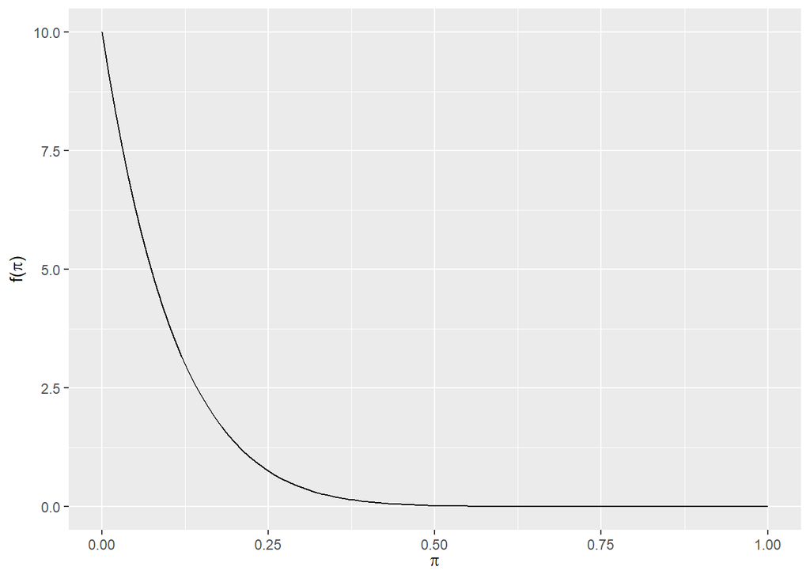

```r
# Visualize the skeptical prior Beta(1, 10)
plot_beta(1, 10)
```

### Step 2: Data Model

Observed data:
$$Y \mid \pi \sim \text{Binomial}(n = 40, \pi), \quad Y = 26$$

We now update the prior using this data.

### Step 3: Posterior Distribution

Since we are using a conjugate Beta prior with a Binomial likelihood, the posterior is:

$$\pi \mid Y = 26 \sim \text{Beta}(1 + 26, 10 + 14) = \text{Beta}(27, 24)$$

### Step 4: Posterior Summary

```r
# Summarize prior and posterior
summarize_beta_binomial(alpha = 1, beta = 10, y = 26, n = 40)
```

```
##       model alpha beta       mean      mode         var         sd
## 1     prior     1   10 0.09090909 0.0000000 0.006887052 0.08298827
## 2 posterior    27   24 0.52941176 0.5306122 0.004791057 0.06921746
```

### Step 5: Posterior Visualization

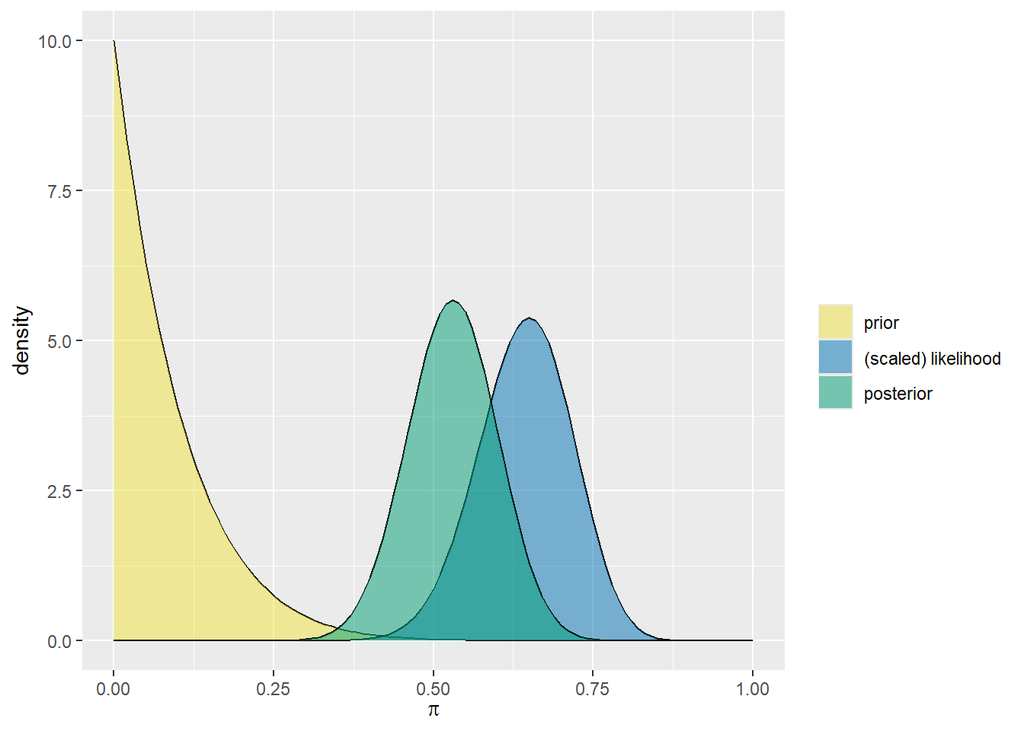

```r
# Plot prior, likelihood (scaled), and posterior
plot_beta_binomial(alpha = 1, beta = 10, y = 26, n = 40)
```

This plot clearly shows the transition from **prior skepticism** (low $\pi$ values) to **posterior learning** from the data (centered near 53%).

### Interpretation

- The prior (Beta(1,10)) assumed that **obedience was rare** (mean around 9%)
- The data (26 out of 40) provided **strong contradictory evidence**
- The posterior (Beta(27,24)) now centers around **53%**, a dramatic shift
- This example illustrates how **Bayesian updating** lets us begin with strong opinions - and still be changed by data